# 市场观察

## D、择时

### (d1)等权指数

从历史来看，A股市场存在小盘股效应，市值小的股票长期整体跑赢大市值的股票，美股市场同样存在类似的现象。而目前大部分指数的编制方案都是类似市值加权，为了抛去市值的影响，下面展示几个等权指数，其中中证500等权和沪深300等权是现有的指数，中证全指等权是自己编制的指数。等权指数可以视为一个更好地业绩比较基准。等权指数走势如下图：

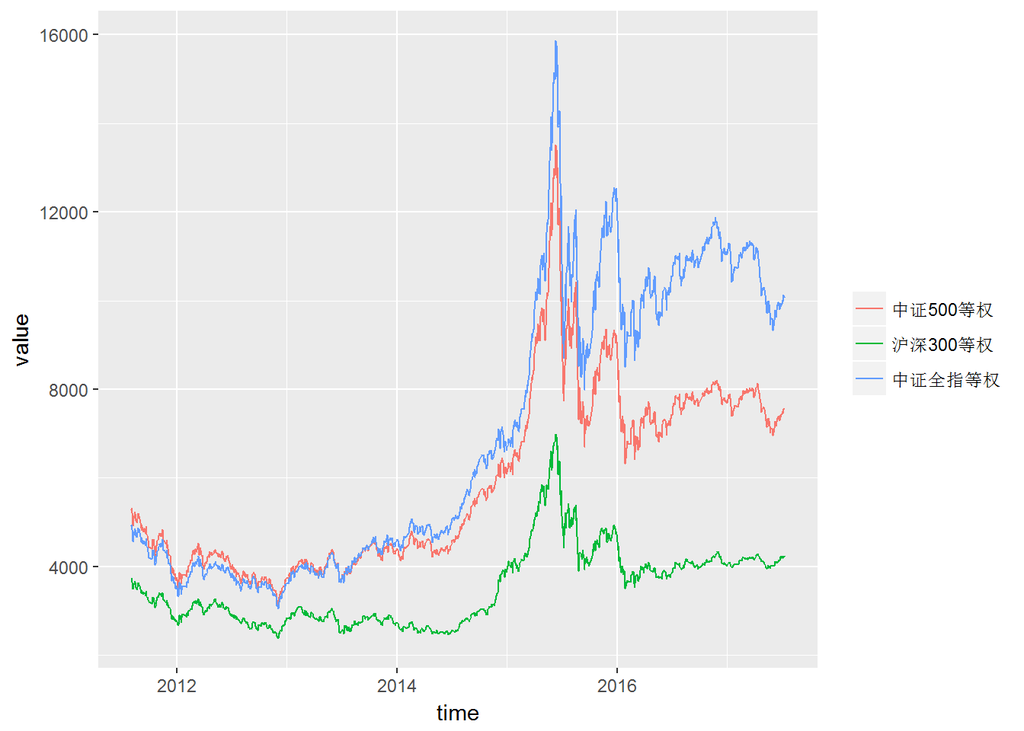

等权指数收益率统计见下表：

|  | 中证500等权 | 沪深300等权 | 中证全指等权 |
| --- | --- | --- | --- |
| 2011-08-02 ~ 2011-12-30 | -29.2% | -25.5% | -27.8% |
| 2012-01-04 ~ 2012-12-31 | -0.0% | 1.5% | 2.2% |
| 2013-01-04 ~ 2013-12-31 | 16.7% | -3.2% | 25.8% |
| 2014-01-02 ~ 2014-12-31 | 40.2% | 43.7% | 46.0% |
| 2015-01-05 ~ 2015-12-31 | 47.6% | 20.1% | 84.4% |
| 2016-01-04 ~ 2016-12-30 | -15.1% | -15.1% | -10.3% |
| 2017-01-03 ~ 2017-07-10 | -2.1% | 4.9% | -8.9% |
| 累计收益率 | 42.1% | 12.6% | 104.2% |
| 年化收益率 | 6.1% | 2.0% | 12.8% |
| 年化波动率 | 28.3% | 25.5% | 28.7% |
| 年化Sharpe值 | 21.5% | 7.9% | 44.5% |
| 最大回撤 | 53.3% | 50.0% | 49.7% |

### (d2)大盘均线强弱指数

大盘均线强弱指数在一定程度上可以视为一个反转指标，当大盘均线得分接近8分时，预示市场接近顶部，当大盘均线得分接近0分时，预示市场接近底部。  
大盘均线强弱指数近一年来走势如下图：

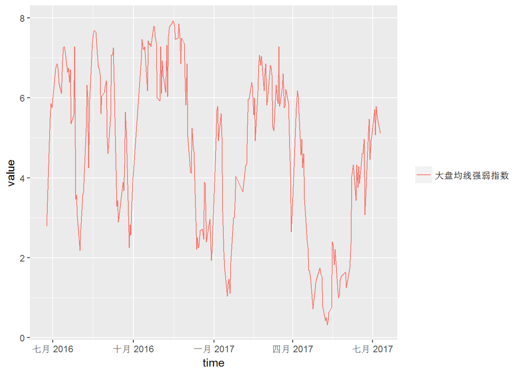

申万一级行业的最新得分见下表：

| 日期 | 指数代码 | 行业 | 最新得分 | 上周得分 |
| --- | --- | --- | --- | --- |
| 2017-07-10 | EI801040 | 钢铁 | 8 | 8 |
| 2017-07-10 | EI801050 | 有色金属 | 8 | 5 |
| 2017-07-10 | EI801170 | 交通运输 | 8 | 6 |
| 2017-07-10 | EI801790 | 非银金融 | 8 | 5 |
| 2017-07-10 | EI801080 | 电子 | 7 | 8 |
| 2017-07-10 | EI801710 | 建筑材料 | 7 | 7 |
| 2017-07-10 | EI801880 | 汽车 | 7 | 8 |
| 2017-07-10 | EI801020 | 采掘 | 6 | 6 |
| 2017-07-10 | EI801180 | 房地产 | 6 | 2 |
| 2017-07-10 | EI801720 | 建筑装饰 | 6 | 4 |
| 2017-07-10 | EI801780 | 银行 | 6 | 7 |
| 2017-07-10 | EI801010 | 农林牧渔 | 5 | 4 |
| 2017-07-10 | EI801030 | 化工 | 5 | 5 |
| 2017-07-10 | EI801110 | 家用电器 | 5 | 6 |
| 2017-07-10 | EI801120 | 食品饮料 | 5 | 5 |
| 2017-07-10 | EI801140 | 轻工制造 | 5 | 5 |
| 2017-07-10 | EI801200 | 商业贸易 | 5 | 5 |
| 2017-07-10 | EI801230 | 综合 | 5 | 5 |
| 2017-07-10 | EI801730 | 电气设备 | 5 | 5 |
| 2017-07-10 | EI801740 | 国防军工 | 5 | 4 |
| 2017-07-10 | EI801890 | 机械设备 | 5 | 4 |
| 2017-07-10 | EI801130 | 纺织服装 | 4 | 2 |
| 2017-07-10 | EI801770 | 通信 | 4 | 5 |
| 2017-07-10 | EI801210 | 休闲服务 | 3 | 5 |
| 2017-07-10 | EI801750 | 计算机 | 3 | 6 |
| 2017-07-10 | EI801150 | 医药生物 | 2 | 6 |
| 2017-07-10 | EI801160 | 公用事业 | 0 | 3 |
| 2017-07-10 | EI801760 | 传媒 | 0 | 1 |

### (d3)LLT及均线择时

LLT本质上是一个改进的单均线择时指标，较原始的均线择时延迟更低。  
择时模型和指数本身的净值走势如下图：

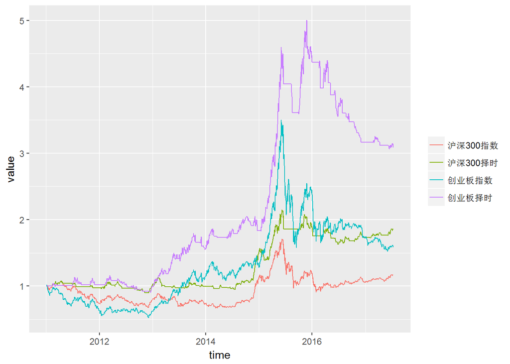

择时模型和指数的收益率统计如下表：

|  | 沪深300指 | 沪深300LLT | 创业板指 | 创业板MA |
| --- | --- | --- | --- | --- |
| 2011-01-04 ~ 2011-12-30 | -25.0% | -2.5% | -35.9% | 1.9% |
| 2012-01-04 ~ 2012-12-31 | 7.6% | 5.4% | -2.1% | -1.7% |
| 2013-01-04 ~ 2013-12-31 | -7.6% | -3.2% | 82.7% | 55.7% |
| 2014-01-02 ~ 2014-12-31 | 51.7% | 52.4% | 12.8% | 17.7% |
| 2015-01-05 ~ 2015-12-31 | 5.6% | 24.3% | 84.4% | 138.1% |
| 2016-01-04 ~ 2016-12-30 | -11.3% | -8.1% | -27.7% | -27.5% |
| 2017-01-03 ~ 2017-07-10 | 10.4% | 6.9% | -8.1% | -2.5% |
| 累计收益率 | 16.8% | 85.4% | 58.5% | 208.6% |
| 年化收益率 | 2.4% | 9.9% | 7.3% | 18.9% |
| 年化波动率 | 23.7% | 15.2% | 32.3% | 21.7% |
| 年化Sharpe值 | 10.2% | 65.2% | 22.7% | 87.0% |
| 最大回撤 | 46.7% | 24.0% | 56.6% | 38.7% |

择时模型最近10个交易日的信号如下表：

| 日期 | 沪深300收盘价 | 沪深300LLT | 沪深300择时信号 | 创业板收盘价 | 创业板MA30 | 创业板择时信号 |
| --- | --- | --- | --- | --- | --- | --- |
| 2017-06-27 | 3674.715 | 3543.298 | hold | 1819.934 | 1791.482 | hold |
| 2017-06-28 | 3646.167 | 3552.580 | hold | 1808.200 | 1792.467 | hold |
| 2017-06-29 | 3668.828 | 3561.189 | hold | 1813.552 | 1792.421 | hold |
| 2017-06-30 | 3666.798 | 3570.017 | hold | 1818.067 | 1792.269 | hold |
| 2017-07-03 | 3650.846 | 3577.795 | hold | 1835.986 | 1793.018 | hold |
| 2017-07-04 | 3619.984 | 3583.637 | hold | 1829.505 | 1793.965 | hold |
| 2017-07-05 | 3659.680 | 3589.445 | hold | 1836.631 | 1795.584 | hold |
| 2017-07-06 | 3660.097 | 3596.237 | hold | 1838.995 | 1798.276 | hold |
| 2017-07-07 | 3655.929 | 3602.537 | hold | 1835.439 | 1800.248 | hold |
| 2017-07-10 | 3653.687 | 3608.282 | hold | 1803.247 | 1801.100 | hold |

### (d4)网格交易

在经历了三轮股灾，A股逐步回归正常，在过去的一段时间呈现一个震荡的格局，如果未来没有增量信息，很可能维持震荡。结合股指期货的贴水，前期研究了一下网格交易。网格交易的结果如下图：

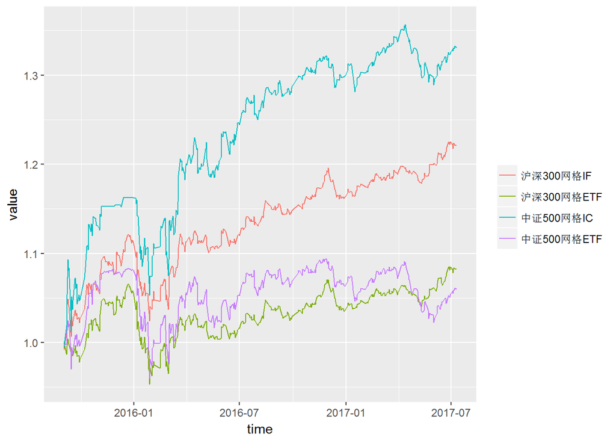

网格交易的收益统计如下表：

|  | 沪深300指数 | 沪深300网格IF | 沪深300网格ETF | 中证500指数 | 中证500网格IC | 中证500网格ETF |
| --- | --- | --- | --- | --- | --- | --- |
| 2015-09-02 ~ 2015-12-31 | 11.0% | 11.1% | 5.6% | 23.5% | 16.2% | 8.1% |
| 2016-01-04 ~ 2016-12-30 | -11.3% | 4.7% | -1.8% | -17.8% | 11.8% | -1.6% |
| 2017-01-03 ~ 2017-07-10 | 10.4% | 5.0% | 4.4% | -0.9% | 2.4% | -0.4% |
| 累计收益率 | 8.7% | 22.2% | 8.2% | 0.6% | 33.1% | 6.0% |
| 年化收益率 | 4.6% | 11.4% | 4.4% | 0.3% | 16.6% | 3.2% |
| 年化波动率 | 20.5% | 8.6% | 8.4% | 27.8% | 12.6% | 10.9% |
| 年化Sharpe值 | 22.3% | 132.7% | 51.9% | 1.2% | 131.3% | 29.1% |
| 最大回撤 | 26.4% | 8.6% | 10.5% | 33.5% | 9.4% | 11.4% |

## E、选股

### (e1)大小市值100

作为多因子选股的第一部分，有必要从市值因子说起。 下面利用总市值因子，在中证全指的成分股内，选出市值最大和最小的100只股票，这里剔除了ST、新上市、停牌和涨停的股票，等权配置，每月换仓一次，交易成本千分之三。观察历年来大、小市值组净值表现如下图。

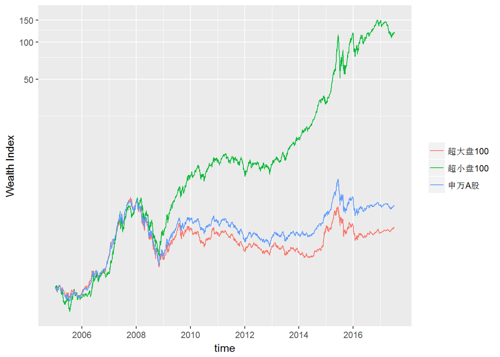

大小市值100的收益统计如下表：

|  | 超大盘100 | 超小盘100 | 申万A股 |
| --- | --- | --- | --- |
| 2005-01-05 ~ 2005-12-30 | -8.0% | -15.5% | -10.1% |
| 2006-01-04 ~ 2006-12-29 | 104.5% | 56.5% | 103.9% |
| 2007-01-04 ~ 2007-12-28 | 163.5% | 270.9% | 167.2% |
| 2008-01-02 ~ 2008-12-31 | -65.6% | -45.1% | -62.8% |
| 2009-01-05 ~ 2009-12-31 | 82.8% | 206.5% | 105.6% |
| 2010-01-04 ~ 2010-12-31 | -9.9% | 32.0% | -6.8% |
| 2011-01-04 ~ 2011-12-30 | -27.2% | -19.5% | -28.6% |
| 2012-01-04 ~ 2012-12-31 | 7.7% | 15.8% | 4.9% |
| 2013-01-04 ~ 2013-12-31 | -9.2% | 65.4% | 6.3% |
| 2014-01-02 ~ 2014-12-31 | 55.5% | 89.8% | 44.9% |
| 2015-01-05 ~ 2015-12-31 | 4.5% | 266.7% | 35.3% |
| 2016-01-04 ~ 2016-12-30 | -13.5% | 24.7% | -13.6% |
| 2017-01-03 ~ 2017-07-10 | 10.8% | -18.8% | -0.0% |
| 累计收益率 | 211.6% | 11735.0% | 370.5% |
| 年化收益率 | 9.5% | 46.4% | 13.2% |
| 年化波动率 | 28.9% | 35.6% | 28.4% |
| 年化Sharpe值 | 32.9% | 130.5% | 46.4% |
| 最大回撤 | 72.9% | 66.4% | 70.5% |

### (e2)银行股轮动

银行股轮动是参考集思录的热门贴银行股评级而来的，数据的提取和参数的设置和原贴有一定的差别，所以轮动的效果也会不太一样，不过回测的效果还不错，从现在开始跟踪。2013年以来银行股轮动的结果如下图：

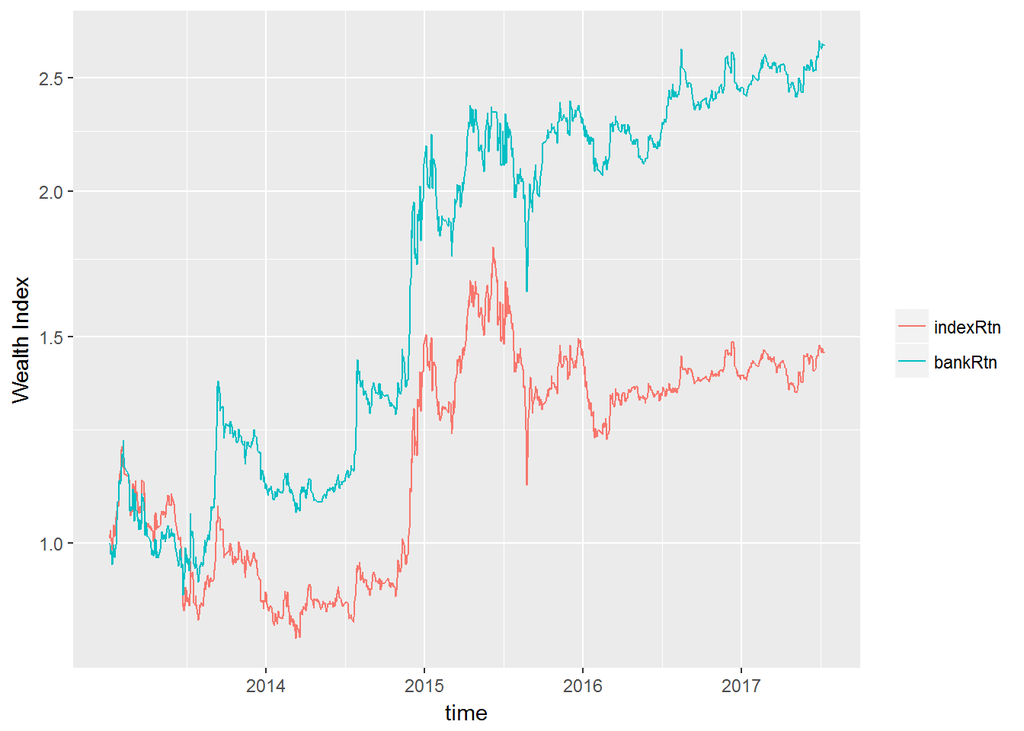

银行股轮动的收益统计如下表：

|  | 申万银行 | 银行股轮动 |
| --- | --- | --- |
| 2013-01-04 ~ 2013-12-31 | -9.2% | 12.5% |
| 2014-01-02 ~ 2014-12-31 | 63.2% | 87.6% |
| 2015-01-05 ~ 2015-12-31 | -1.4% | 9.4% |
| 2016-01-04 ~ 2016-12-30 | -4.9% | 6.2% |
| 2017-01-04 ~ 2017-07-10 | 4.7% | 8.9% |
| 累计收益率 | 45.5% | 167.1% |
| 年化收益率 | 8.6% | 24.3% |
| 年化波动率 | 27.5% | 29.4% |
| 年化Sharpe值 | 31.4% | 82.5% |
| 最大回撤 | 37.4% | 30.8% |

银行股轮动的最新得分如下表：

| 日期 | 代码 | 简称 | PB | ROE | 翻倍期 | 持仓 |
| --- | --- | --- | --- | --- | --- | --- |
| 2017-07-10 | EQ601328 | 交通银行 | 0.70 | 0.10 | 3.4 |  |
| 2017-07-10 | EQ601818 | 光大银行 | 0.74 | 0.12 | 3.6 |  |
| 2017-07-10 | EQ600015 | 华夏银行 | 0.78 | 0.13 | 3.7 | hold |
| 2017-07-10 | EQ601988 | 中国银行 | 0.77 | 0.11 | 4.0 |  |
| 2017-07-10 | EQ600016 | 民生银行 | 0.86 | 0.14 | 4.2 |  |
| 2017-07-10 | EQ601288 | 农业银行 | 0.87 | 0.14 | 4.3 |  |
| 2017-07-10 | EQ601998 | 中信银行 | 0.80 | 0.11 | 4.6 |  |
| 2017-07-10 | EQ000001 | 平安银行 | 0.81 | 0.11 | 4.7 |  |
| 2017-07-10 | EQ600000 | 浦发银行 | 0.96 | 0.14 | 4.9 |  |
| 2017-07-10 | EQ601939 | 建设银行 | 0.96 | 0.14 | 4.9 |  |
| 2017-07-10 | EQ601398 | 工商银行 | 0.95 | 0.14 | 5.0 |  |
| 2017-07-10 | EQ601166 | 兴业银行 | 1.02 | 0.14 | 5.4 |  |
| 2017-07-10 | EQ601169 | 北京银行 | 0.98 | 0.12 | 5.8 |  |
| 2017-07-10 | EQ601009 | 南京银行 | 1.08 | 0.13 | 6.1 |  |
| 2017-07-10 | EQ002142 | 宁波银行 | 1.50 | 0.16 | 7.5 |  |
| 2017-07-10 | EQ600036 | 招商银行 | 1.46 | 0.15 | 7.6 |  |
| 2017-07-10 | EQ601997 | 贵阳银行 | 1.69 | 0.17 | 7.6 |  |
| 2017-07-10 | EQ600919 | 江苏银行 | 1.28 | 0.13 | 7.8 |  |
| 2017-07-10 | EQ601229 | 上海银行 | 1.30 | 0.12 | 8.3 |  |
| 2017-07-10 | EQ600926 | 杭州银行 | 1.39 | 0.10 | 10.4 |  |
| 2017-07-10 | EQ601128 | 常熟银行 | 2.48 | 0.11 | 15.9 |  |
| 2017-07-10 | EQ600908 | 无锡银行 | 2.61 | 0.10 | 16.9 |  |
| 2017-07-10 | EQ603323 | 吴江银行 | 2.18 | 0.08 | 18.2 |  |
| 2017-07-10 | EQ002807 | 江阴银行 | 2.51 | 0.09 | 19.2 |  |
| 2017-07-10 | EQ002839 | 张家港行 | 3.75 | 0.09 | 24.4 |  |

## F、多因子跟踪

### (f1)近一个月周频因子IC

全市场因子IC表现如下图所示，根据因子IC均值大于0，胜率大于50%简单区分了一下alpha因子和风险因子。

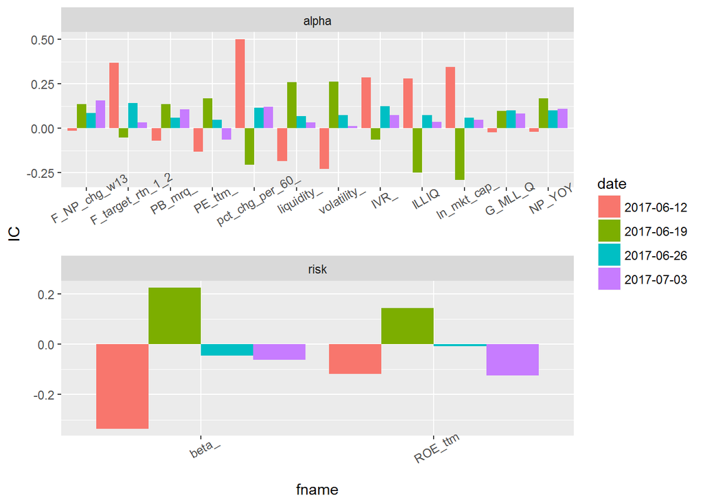

沪深300因子IC表现如下图所示。

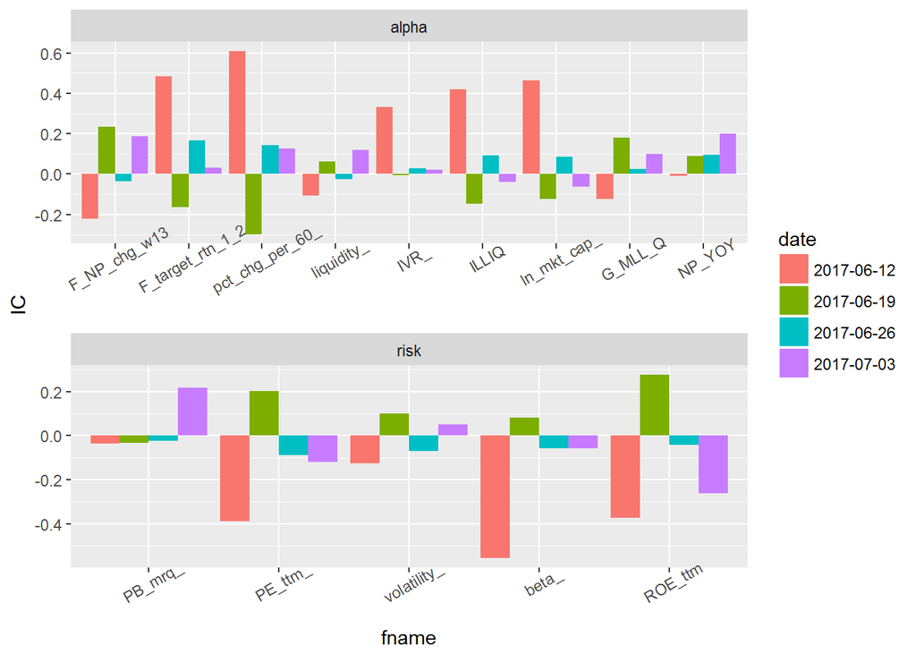

中证500因子IC表现如下图所示。

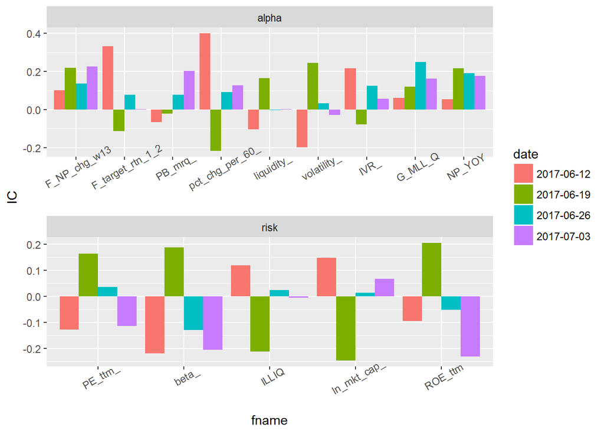

因子IC统计如下表所示。

| 因子名 | 全市场排名 | 全市场均值 | 全市场胜率 | 沪深300排名 | 沪深300均值 | 沪深300胜率 | 中证500排名 | 中证500均值 | 中证500胜率 |
| --- | --- | --- | --- | --- | --- | --- | --- | --- | --- |
| pct_chg_per_60_ | 1 | 0.133 | 0.75 | 1 | 0.145 | 0.75 | 4 | 0.100 | 0.75 |
| F_target_rtn_1_2 | 2 | 0.123 | 0.75 | 2 | 0.129 | 0.75 | 6 | 0.075 | 0.75 |
| IVR_ | 3 | 0.105 | 0.75 | 4 | 0.093 | 0.75 | 5 | 0.080 | 0.75 |
| F_NP_chg_w13 | 4 | 0.091 | 0.75 | 8 | 0.040 | 0.50 | 1 | 0.171 | 1.00 |
| NP_YOY | 5 | 0.089 | 0.75 | 3 | 0.095 | 0.75 | 2 | 0.160 | 1.00 |
| G_MLL_Q | 6 | 0.065 | 0.75 | 7 | 0.046 | 0.75 | 3 | 0.148 | 1.00 |
| PB_mrq_ | 7 | 0.057 | 0.75 | 9 | 0.031 | 0.25 | 7 | 0.048 | 0.50 |
| liquidity_ | 8 | 0.045 | 0.75 | 10 | 0.012 | 0.50 | 8 | 0.014 | 0.50 |
| ln_mkt_cap_ | 9 | 0.040 | 0.75 | 5 | 0.091 | 0.50 | 10 | -0.004 | 0.75 |
| ILLIQ | 10 | 0.036 | 0.75 | 6 | 0.082 | 0.50 | 12 | -0.018 | 0.50 |
| volatility_ | 11 | 0.030 | 0.75 | 11 | -0.012 | 0.50 | 9 | 0.012 | 0.50 |
| PE_ttm_ | 12 | 0.005 | 0.50 | 12 | -0.098 | 0.25 | 11 | -0.010 | 0.50 |
| ROE_ttm | 13 | -0.027 | 0.25 | 13 | -0.100 | 0.25 | 13 | -0.043 | 0.25 |
| beta_ | 14 | -0.055 | 0.25 | 14 | -0.147 | 0.25 | 14 | -0.092 | 0.25 |

### (f2)近一个月周频因子分组超额收益

全市场，不同时间段，根据因子得分分为10组，得分最高的组**超额**收益率如下图所示，根据累计收益率大于0和区间收益率为正概率大于0.5,简单区分了alpha因子和风险因子。

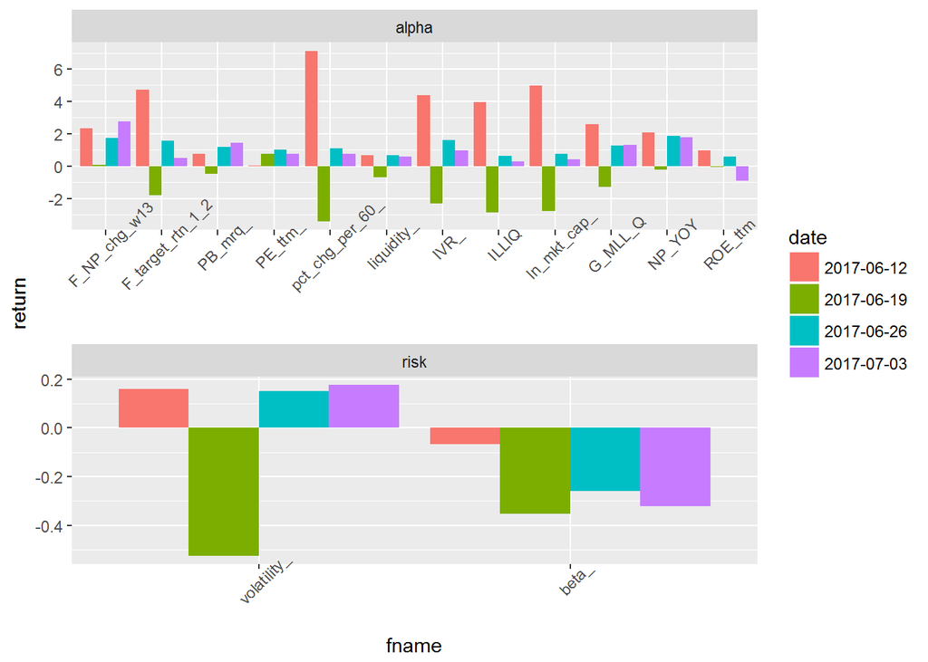

沪深300内得分最高的组**超额**收益率如下图所示。

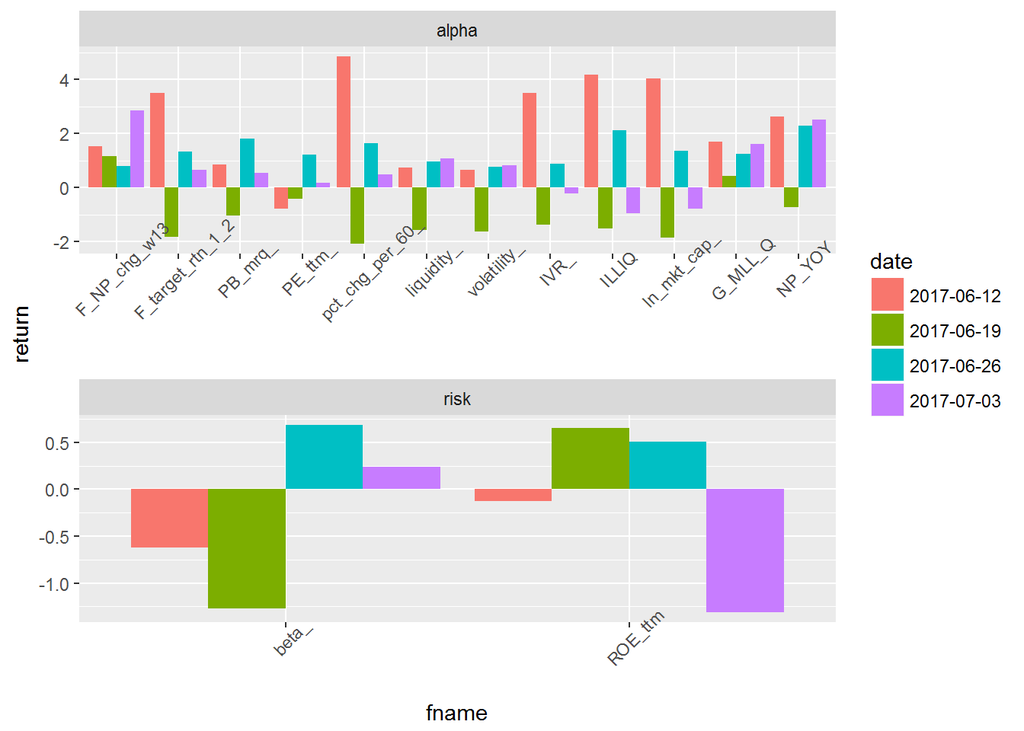

中证500内得分最高的组**超额**收益率如下图所示。

[figure not shown]

各个样本空间内，因子得分最高的一组和得分最低的一组的**超额**累积收益率统计如下表所示。

| 因子名 | 全市场Q1 | 全市场Q10 | 沪深300Q1 | 沪深300Q10 | 中证500Q1 | 中证500Q10 |
| --- | --- | --- | --- | --- | --- | --- |
| F_NP_chg_w13 | 7.0 | 1.6 | 6.4 | 2.7 | 10.9 | 0.6 |
| NP_YOY | 5.6 | 0.9 | 6.8 | 1.4 | 6.8 | -0.4 |
| pct_chg_per_60_ | 5.4 | -3.0 | 4.9 | -2.3 | 3.6 | -2.8 |
| F_target_rtn_1_2 | 4.9 | -3.1 | 3.6 | -2.8 | 3.7 | -0.7 |
| IVR_ | 4.6 | -1.1 | 2.8 | -0.8 | 2.6 | -1.5 |
| G_MLL_Q | 3.9 | -0.5 | 5.1 | 1.6 | 4.7 | -2.4 |
| ln_mkt_cap_ | 3.2 | -0.2 | 2.7 | -0.1 | 0.6 | -0.3 |
| PB_mrq_ | 2.9 | -0.5 | 2.1 | 0.1 | 3.0 | -1.6 |
| PE_ttm_ | 2.6 | 2.1 | 0.2 | 5.7 | 2.0 | 1.4 |
| ILLIQ | 1.9 | -0.5 | 3.8 | -0.1 | 0.9 | 0.2 |
| liquidity_ | 1.2 | -2.0 | 1.2 | 0.0 | 0.8 | -1.4 |
| ROE_ttm | 0.6 | 1.8 | -0.3 | 5.9 | -0.5 | 1.8 |
| volatility_ | 0.0 | -0.6 | 0.6 | 1.2 | -1.6 | -1.1 |
| beta_ | -1.0 | 2.2 | -1.0 | 7.6 | -2.4 | 1.6 |

### (f3)近一年月频因子IC

全市场因子IC表现如下图所示。

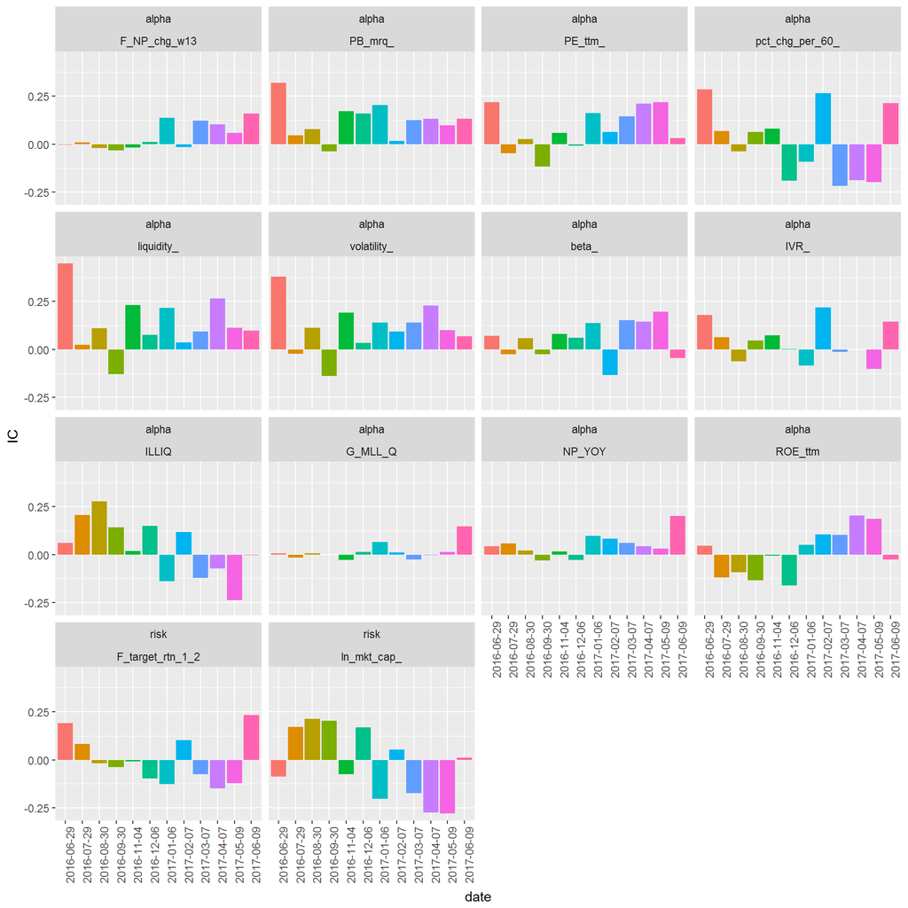

沪深300因子IC表现如下图所示。

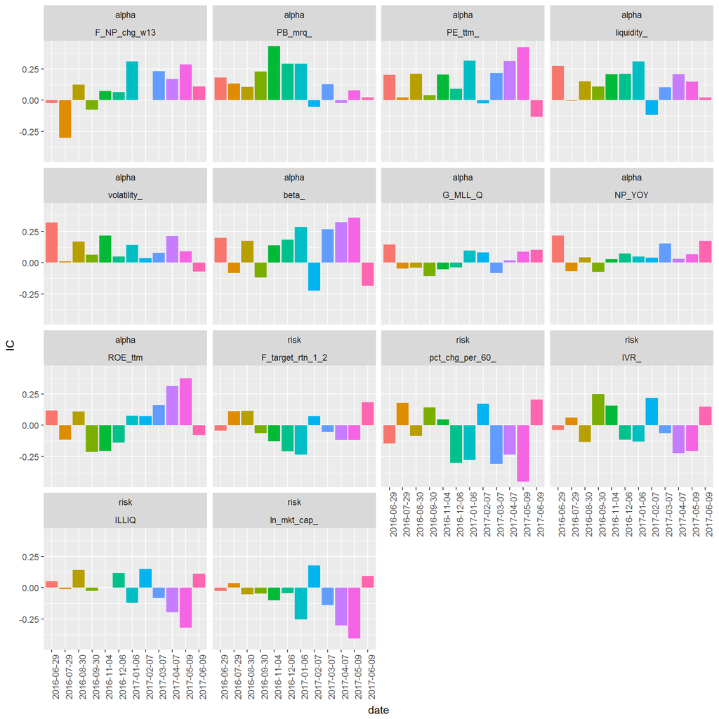

中证500因子IC表现如下图所示。

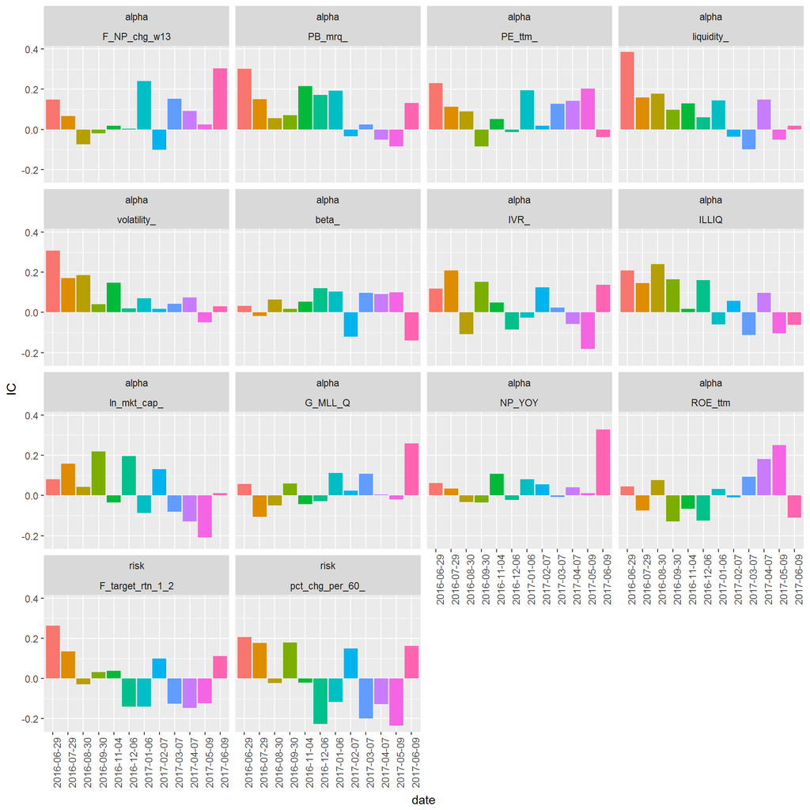

因子IC统计如下表所示。

|  | 因子名 | 全市场排名 | 全市场均值 | 全市场胜率 | 沪深300排名 | 沪深300均值 | 沪深300胜率 | 中证500排名 | 中证500均值 | 中证500胜率 |
| --- | --- | --- | --- | --- | --- | --- | --- | --- | --- | --- |
| 15 | liquidity_ | 1 | 0.131 | 0.92 | 3 | 0.135 | 0.83 | 2 | 0.094 | 0.75 |
| 16 | PB_mrq_ | 2 | 0.120 | 0.92 | 2 | 0.152 | 0.83 | 1 | 0.095 | 0.75 |
| 17 | volatility_ | 3 | 0.110 | 0.83 | 5 | 0.110 | 0.92 | 3 | 0.088 | 0.92 |
| 18 | PE_ttm_ | 4 | 0.080 | 0.75 | 1 | 0.157 | 0.83 | 4 | 0.086 | 0.75 |
| 19 | beta_ | 5 | 0.056 | 0.67 | 4 | 0.111 | 0.67 | 8 | 0.033 | 0.75 |
| 20 | NP_YOY | 6 | 0.049 | 0.83 | 7 | 0.061 | 0.83 | 7 | 0.052 | 0.67 |
| 21 | F_NP_chg_w13 | 7 | 0.043 | 0.58 | 6 | 0.081 | 0.75 | 5 | 0.071 | 0.75 |
| 22 | IVR_ | 8 | 0.039 | 0.58 | 10 | -0.007 | 0.42 | 10 | 0.030 | 0.58 |
| 23 | ILLIQ | 9 | 0.033 | 0.58 | 11 | -0.016 | 0.50 | 6 | 0.063 | 0.67 |
| 24 | G_MLL_Q | 10 | 0.016 | 0.58 | 9 | 0.014 | 0.50 | 9 | 0.031 | 0.58 |
| 25 | ROE_ttm | 11 | 0.013 | 0.50 | 8 | 0.038 | 0.58 | 12 | 0.014 | 0.50 |
| 26 | pct_chg_per_60_ | 12 | 0.005 | 0.50 | 13 | -0.089 | 0.42 | 14 | -0.006 | 0.42 |
| 27 | F_target_rtn_1_2 | 13 | -0.002 | 0.33 | 12 | -0.041 | 0.33 | 13 | -0.002 | 0.50 |
| 28 | ln_mkt_cap_ | 14 | -0.023 | 0.50 | 14 | -0.089 | 0.25 | 11 | 0.025 | 0.58 |

### (f4)近一年月频因子分组超额收益

全市场，不同时间段，根据因子得分分为10组，得分最高的组**超额**收益率如下图所示，根据累计收益率大于0和区间收益率为正概率大于0.5,简单区分了alpha因子和风险因子。

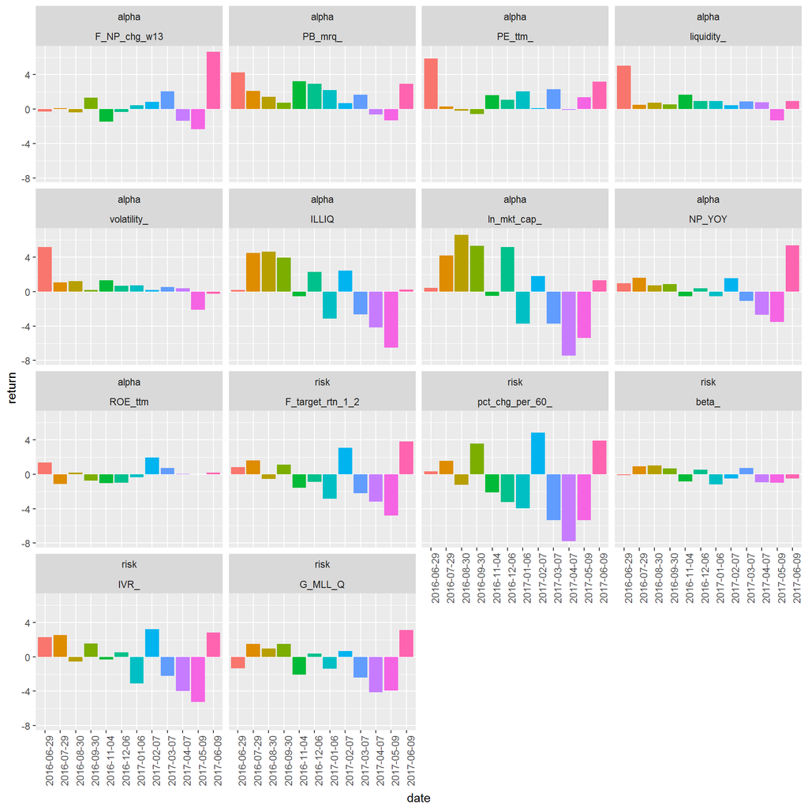

沪深300内得分最高的组**超额**收益率如下图所示。

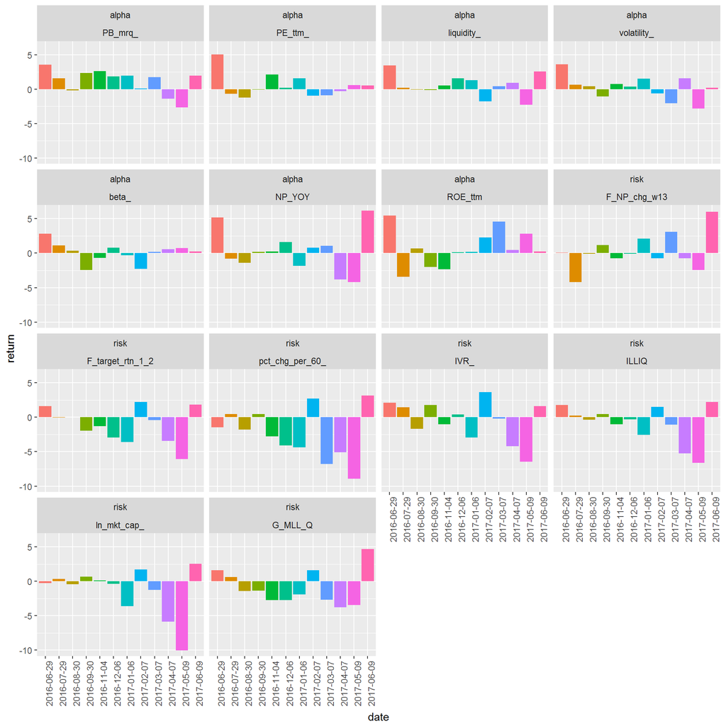

中证500内得分最高的组**超额**收益率如下图所示。

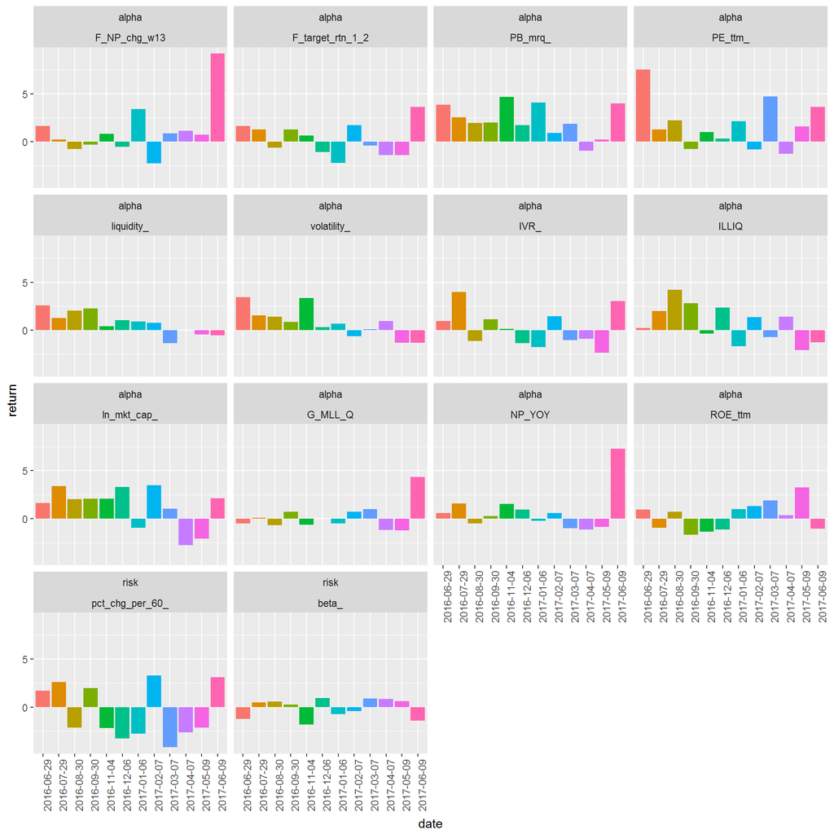

各个样本空间内，因子得分最高的一组和得分最低的一组的**超额**累积收益率统计如下表所示。

|  | 因子名 | 全市场Q1 | 全市场Q10 | 沪深300Q1 | 沪深300Q10 | 中证500Q1 | 中证500Q10 |
| --- | --- | --- | --- | --- | --- | --- | --- |
| 15 | PB_mrq_ | 21.8 | -25.9 | 14.2 | -22.2 | 30.2 | -8.3 |
| 16 | PE_ttm_ | 18.1 | -15.2 | 5.8 | -23.3 | 23.4 | -8.4 |
| 17 | liquidity_ | 12.5 | -31.8 | 6.7 | -25.8 | 9.2 | -18.0 |
| 18 | volatility_ | 9.4 | -23.9 | 2.3 | -23.7 | 9.7 | -15.9 |
| 19 | F_NP_chg_w13 | 4.9 | -11.6 | 3.1 | -16.6 | 14.7 | -12.3 |
| 20 | ln_mkt_cap_ | 2.9 | 8.0 | -15.9 | 9.5 | 16.2 | 3.0 |
| 21 | NP_YOY | 2.8 | -12.3 | 2.7 | -13.6 | 9.2 | -7.2 |
| 22 | ILLIQ | 0.4 | -7.4 | -10.9 | 1.7 | 8.3 | -16.0 |
| 23 | ROE_ttm | 0.1 | -5.9 | 9.2 | -3.0 | 3.3 | 1.5 |
| 24 | beta_ | -1.3 | -23.6 | 1.0 | -27.4 | -1.0 | -18.7 |
| 25 | IVR_ | -2.9 | -10.5 | -5.7 | -2.4 | 2.0 | 0.0 |
| 26 | F_target_rtn_1_2 | -5.9 | -8.3 | -13.6 | -8.1 | 2.9 | 1.7 |
| 27 | G_MLL_Q | -7.2 | -10.3 | -11.2 | -13.0 | 2.1 | -5.5 |
| 28 | pct_chg_per_60_ | -14.8 | -12.4 | -25.7 | 3.6 | -6.8 | -5.6 |